# Gene-set analysis

# Gene-set analysis

### Introduction and data

The follwing packages are used in this tutorial: `DESeq2`, `biomaRt`, `piano`, `snow`, `snowfall`. In case you haven’t installed them yet it could be convenient to do so before starting (you can potentially skip `snow` and `snowfall`). We will perform gene-set analysis on the output from the tutorial on Differential expression analysis of RNA-seq data using DESeq. A quick recap of the essential code for the differential expression analysis is included below, in case you did not save the output from that analysis:

```r
library(DESeq2)
counts <- read.delim("count_table.txt")
samples <- data.frame(timepoint = rep(c("ctrl", "t2h", "t6h", "t24h"), each=3))
ds <- DESeqDataSetFromMatrix(countData=counts, colData=samples, design=~timepoint)
colnames(ds) <- colnames(counts)
ds <- DESeq(ds)
res <- results(ds, c("timepoint","t24h","ctrl"))
res <- res[ ! (is.na(res$pvalue) | is.na(res$padj)), ]
# Here we also exclude genes with adjusted p-values = NA
```

Let’s save the information we need (fold-changes and adjusted p-values):

```r
geneLevelStats <- as.data.frame(res[,c("log2FoldChange","padj")])
```

It will be handy to have the gene names along with the Ensembl IDs, so let’s fetch them:

```r
library(biomaRt) # Install the biomaRt package (Bioconductor) if this command does not work

# Get the Ensembl ID to gene name mapping:
mart <- useMart("ENSEMBL_MART_ENSEMBL", dataset = "hsapiens_gene_ensembl", host="www.ensembl.org")
ensembl2name <- getBM(attributes=c("ensembl_gene_id","external_gene_name"),mart=mart)

# Merge it with our gene-level statistics:
geneLevelStats <- merge(x=geneLevelStats, y=ensembl2name, by.x=0, by.y=1, all.x=TRUE)
colnames(geneLevelStats) <- c("ensembl","log2fc","padj","gene")
rownames(geneLevelStats) <- geneLevelStats[,1]

# Sort the gene-level statistics by adjusted p-value:
geneLevelStats <- geneLevelStats[order(geneLevelStats$padj),]
head(geneLevelStats)
```

```
##                         ensembl    log2fc          padj    gene
## ENSG00000104738 ENSG00000104738 -2.210535  0.000000e+00    MCM4
## ENSG00000118849 ENSG00000118849  3.550871  0.000000e+00 RARRES1
## ENSG00000163283 ENSG00000163283  4.318265  0.000000e+00    ALPP
## ENSG00000171848 ENSG00000171848 -2.717818  0.000000e+00    RRM2
## ENSG00000182481 ENSG00000182481 -2.062894  0.000000e+00   KPNA2
## ENSG00000110092 ENSG00000110092 -2.469861 2.849282e-302   CCND1
```

### Gene-set analysis

Looking at only the top 100 genes (or genes with a adjusted p-value below some cutoff) has the drawback of excluding a lot of information. Gene-set analysis (GSA) takes into account the “scores” (which can be e.g. p-values, fold-changes, etc) of all genes. This allows us to also detect small but coordinate changes converging on specific biological functions or other themes. In this tutorial we will use the piano package to perform GSA:

```r
#source("http://bioconductor.org/biocLite.R")
#biocLite("piano")


library(piano) # Install the piano package (Bioconductor) if this command does not work
```

First we need to construct our gene-set collection, we will be looking at so called Hallmark gene-sets from the MSigDB in this example (see this paper). Download the Hallmark gene-set collection from [here](http://software.broadinstitute.org/gsea/msigdb/download_file.jsp?filePath=/resources/msigdb/5.1/h.all.v5.1.symbols.gmt). Note that you need to sign up with an email adress to gain access. Visit [this link](http://software.broadinstitute.org/gsea/msigdb/collections.jsp#H) if the first link does not work.

```r
# Load the gene-set collection into piano format:
gsc <- loadGSC("h.all.v5.1.symbols.gmt", type="gmt") # Check that the filename matches the file that you downloaded
gsc # Always take a look at the GSC object to see that it loaded correctly
```

```
## First 50 (out of 50) gene set names:
##  [1] "HALLMARK_TNFA_S..." "HALLMARK_HYPOXI..." "HALLMARK_CHOLES..."
##  [4] "HALLMARK_MITOTI..." "HALLMARK_WNT_BE..." "HALLMARK_TGF_BE..."
##  [7] "HALLMARK_IL6_JA..." "HALLMARK_DNA_RE..." "HALLMARK_G2M_CH..."
## [10] "HALLMARK_APOPTO..." "HALLMARK_NOTCH_..." "HALLMARK_ADIPOG..."
## [13] "HALLMARK_ESTROG..." "HALLMARK_ESTROG..." "HALLMARK_ANDROG..."
## [16] "HALLMARK_MYOGEN..." "HALLMARK_PROTEI..." "HALLMARK_INTERF..."
## [19] "HALLMARK_INTERF..." "HALLMARK_APICAL..." "HALLMARK_APICAL..."
## [22] "HALLMARK_HEDGEH..." "HALLMARK_COMPLE..." "HALLMARK_UNFOLD..."
## [25] "HALLMARK_PI3K_A..." "HALLMARK_MTORC1..." "HALLMARK_E2F_TA..."
## [28] "HALLMARK_MYC_TA..." "HALLMARK_MYC_TA..." "HALLMARK_EPITHE..."
## [31] "HALLMARK_INFLAM..." "HALLMARK_XENOBI..." "HALLMARK_FATTY_..."
## [34] "HALLMARK_OXIDAT..." "HALLMARK_GLYCOL..." "HALLMARK_REACTI..."
## [37] "HALLMARK_P53_PA..." "HALLMARK_UV_RES..." "HALLMARK_UV_RES..."
## [40] "HALLMARK_ANGIOG..." "HALLMARK_HEME_M..." "HALLMARK_COAGUL..."
```

[output cut: 20 more lines]

Now we are ready to run the GSA:

```r
#library(snowfall); library(snow) # Install snow and snowfall (CRAN) if you want to
# run on multiple cores, otherwise omit the ncpus argument below in the call to runGSA
padj <- geneLevelStats$padj
log2fc <- geneLevelStats$log2fc
names(padj) <- names(log2fc) <- geneLevelStats$gene
gsaRes <- runGSA(padj, log2fc, gsc=gsc)
```

```
## Running gene set analysis:
```

```
## Checking arguments...
```

```
## done!
```

```
## Final gene/gene-set association: 3457 genes and 50 gene sets
```

```
##   Details:
```

```
##   Using all 19606 gene-level statistics for significance estimation
```

```
##   Removed 929 genes from GSC due to lack of matching gene statistics
```

```
##   Removed 0 gene sets containing no genes after gene removal
```

```
##   Removed additionally 0 gene sets not matching the size limits
```

```
##   Loaded additional information for 50 gene sets
```

```
## Adjusting for multiple testing...done!
```

The runGSA function uses the adjusted p-values to score the genes and the log2-foldchange for information about the direction of change.

We can visualize the results in different ways, for instance using a network plot showing the significant gene-sets and the overlap of genes between sets:

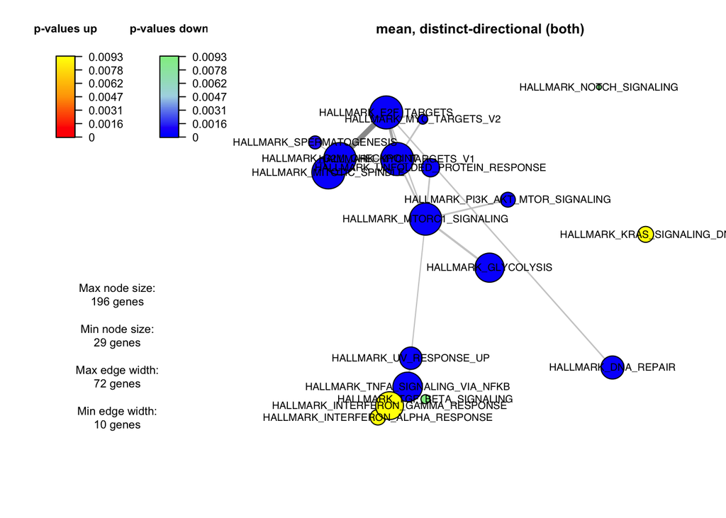

```r
networkPlot(gsaRes, "distinct", "both", adjusted=T, ncharLabel=Inf, significance=0.01,
            nodeSize=c(3,20), edgeWidth=c(1,5), overlap=10,
            scoreColors=c("red", "orange", "yellow", "blue", "lightblue", "lightgreen"))
```

The function `GSAsummaryTable` can be used to export the complete results.

```r
GSAsummaryTable(gsaRes)
```

```
##                                          Name Genes (tot)
## 1            HALLMARK_TNFA_SIGNALING_VIA_NFKB         175
## 2                            HALLMARK_HYPOXIA         165
## 3            HALLMARK_CHOLESTEROL_HOMEOSTASIS          70
## 4                    HALLMARK_MITOTIC_SPINDLE         196
## 5         HALLMARK_WNT_BETA_CATENIN_SIGNALING          32
## 6                 HALLMARK_TGF_BETA_SIGNALING          53
## 7            HALLMARK_IL6_JAK_STAT3_SIGNALING          63
## 8                         HALLMARK_DNA_REPAIR         137
## 9                     HALLMARK_G2M_CHECKPOINT         192
## 10                         HALLMARK_APOPTOSIS         137
## 11                   HALLMARK_NOTCH_SIGNALING          29
## 12                      HALLMARK_ADIPOGENESIS         172
## 13           HALLMARK_ESTROGEN_RESPONSE_EARLY         168
## 14            HALLMARK_ESTROGEN_RESPONSE_LATE         171
```

[output cut: 291 more lines]

```r
# if you want to you can also save this as a file:
# GSAsummaryTable(gsaRes, save=T, file="gsares.txt")
```

The `geneSetSummary` function can be used to explore specific gene-sets in more detail.

For instance, we can make a boxplot of the -log10(adjusted p-values) of the genes in the gene-set HALLMARK_DNA_REPAIR and compare that to the distribution of all genes:

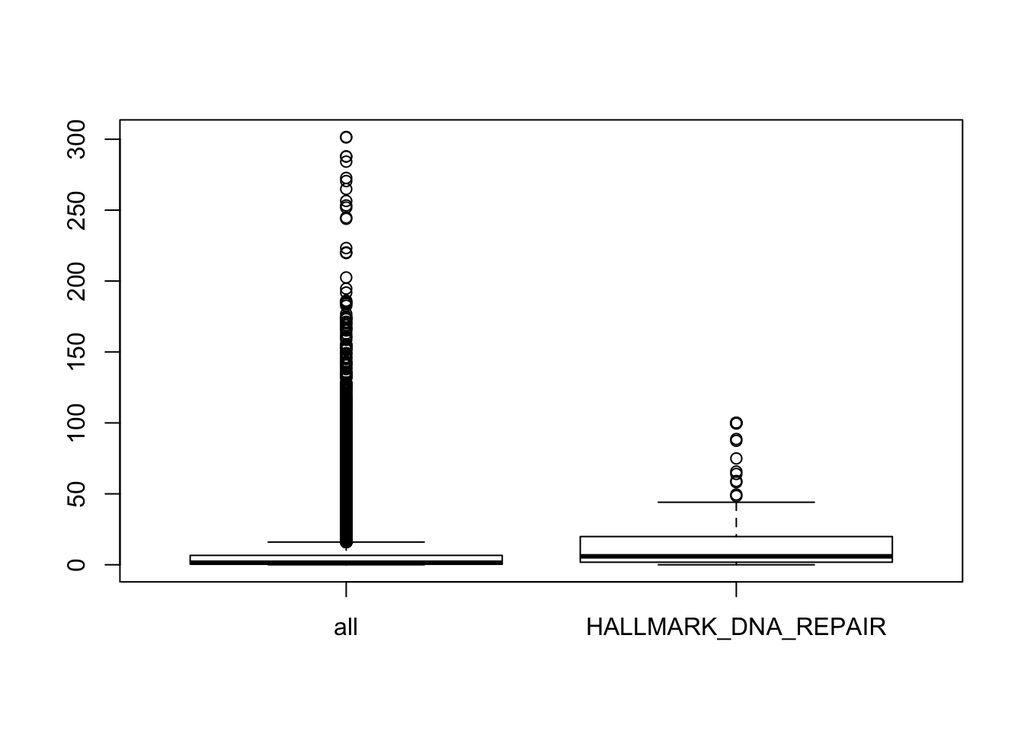

```r
boxplot(list(-log10(geneLevelStats$padj),
             -log10(geneSetSummary(gsaRes,"HALLMARK_DNA_REPAIR")$geneLevelStats)),
        names=c("all","HALLMARK_DNA_REPAIR"))
```

From here, you can dig in to the results on the gene-set level further and start making hypothesis of what is happening with the biology behind your data. You can also try to run GSA with other gene-set collections (e.g. from [MSigDB](http://software.broadinstitute.org/gsea/msigdb/)) or using another GSA method (see `?runGSA`).

### Further reading

- Piano webpage, with more information and link to publication: http://www.sysbio.se/piano
- GSEA paper: http://www.pnas.org/content/102/43/15545.full
- A couple of reviews:
- http://bib.oxfordjournals.org/content/9/3/189.full
- http://bmcbioinformatics.biomedcentral.com/articles/10.1186/1471-2105-10-47